# Happiness and Music

Laura Read

2022-05-24

## Introduction

This report was my final **STATS 220: Data Technologies** assignment. I was marked on my ability to create data from digital sources, such as web scraping using `HTML` and obtaining information from an `API`. The information I obtained then needed to be visualised using various `R` packages in `rStudio`. My assignment received an A+ grade.

To provide my assignment with context, I chose to investigate the popular music listening habits of the top 4 happiest countries in the world. In particular, looking to see if there was any correlation between track rank and track duration.

According to the [World Happiness Report 2022](https://worldhappiness.report/ed/2022/happiness-benevolence-and-trust-during-covid-19-and-beyond/#ranking-of-happiness-2019-2021), the top 5 happiest countries are:

1. Finland
2. Denmark
3. Iceland
4. Switzerland
5. Netherlands.

Apple Music compiles a daily list of the top 100 songs played using their streaming service in various countries around the world. Note that Iceland does not have a top 100 list, so it has been excluded from the report. Data was scraped from the four *Top 100* webpages to acquire songs and rank. Track duration was sourced from the *iTunes* API.

## Visualisation

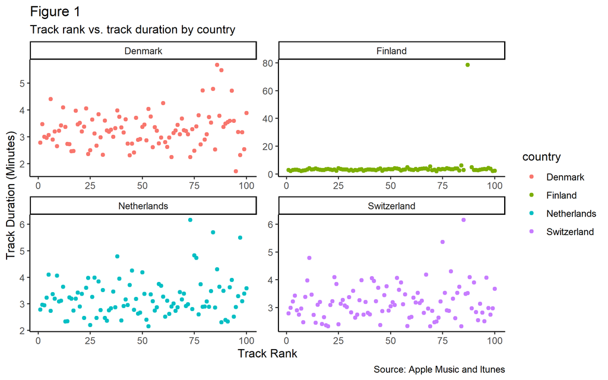

Figure 1

**Figure 1** displays no correlation between track rank and track duration. However, on first impressions Denmark, Switzerland and the Netherlands seem to display a few outliers where the track duration is between 5 and 6 minutes in the lowest ranking songs (between 75 to 100). Interestingly, Finland’s plot is distorted by the track *White Noise Long* which is 78.7 minutes long, ranked at #87.

## Data creation

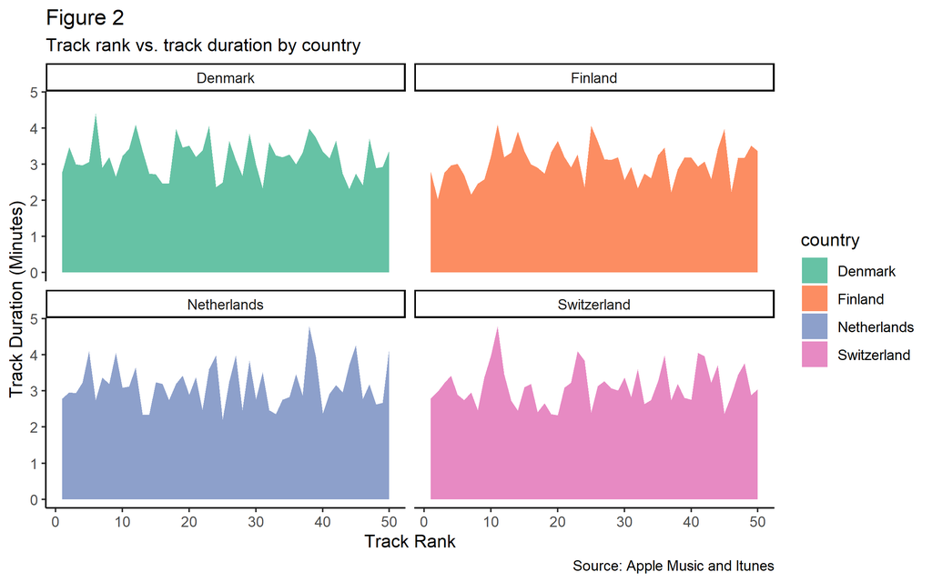

Figure 2

I created a second `geom_area` plot to further investigate track rank and track duration to see if there appeared to be a similar trend across the four countries. To limit plot distortion due to outliers, I arranged the data into a new table by track rank, then sliced the first 200 rows so I would only display the top 50 ranked songs per country. By narrowing down the dataset, I excluded the outlying track durations. However, despite halving the dataset, **figure 2** does not seem to display a trend of track duration changing over the progression of track rank.

## Reflection

An important idea I learned from Module 5 was responsible web scraping. I can now inspect a page’s HTML to find the variables needed to read into `R` using functions such as `Sys.sleep` and `html_elements`. Keeping in mind to avoid collecting any data that could personally identify someone and to check if the website allows automated data copying processes.

Overall, this course has taught me how to manipulate data to produce visually appealing and creative images and plots that aid communication in dynamic reporting. As I progress in my university career, I would like to explore ways to communicate geospatial datasets using the `ggplot2`package and other packages that allow me to map datasets. Finally, I would be interested in exploring how to develop my own functions further.

## Code Appendix

```r
library(tidyverse)
library(rvest)
library(lubridate)

urls <- c("https://music.apple.com/us/playlist/top-100-finland/pl.acea41a017664a8ebcd5aa1622aecc88",
          "https://music.apple.com/us/playlist/top-100-denmark/pl.d08496850bc840a4874e877177a69f9f",
          "https://music.apple.com/us/playlist/top-100-switzerland/pl.bb1f5218a0f04de3877c4f9ccd63d260",
          "https://music.apple.com/us/playlist/top-100-netherlands/pl.26fb1998d54a4b3192be548529a97f8e")

countries <- c("Finland", "Denmark", "Switzerland", "Netherlands")

apple_data <- map_df(1 : length(urls), function(i){

  Sys.sleep(2)

  page <- read_html(urls[i])
  country <- countries[i]

  trackId <- page %>%
    html_elements(".songs-list") %>%
    html_elements("a") %>%
    html_attr("href") %>%
    .[str_detect(., "song")] %>%
    str_remove_all("https://music.apple.com/us/song/") %>%
    as.numeric()

  trackRank <- page %>%
    html_elements(".songs-list-row__rank") %>%
    html_text2()

  trackArtist <- page %>%
    html_elements(".songs-list-row__by-line") %>%
    html_text2()

  return(tibble(trackId, trackRank, dateScraped = now(), trackArtist, country))
})

saveRDS(apple_data, "apple_data.rds")
```

```r
library(tidyverse)
library(jsonlite)

apple_data <- readRDS("apple_data.rds")

trackIds <- apple_data$trackId %>%
  unique() %>%
  na.omit()

itunes_data <- map_df(1 : length(trackIds), function(i){

  Sys.sleep(2)
  print(i)

  song_id <- trackIds[i]
  url <- paste0("https://itunes.apple.com/lookup?id=", song_id)
  response <- fromJSON(url)

  itunes_data <- response$results
})


saveRDS(itunes_data, "itunes_data.rds")
```

```r
library(tidyverse)

apple_data <- readRDS("apple_data.rds")
itunes_data <- readRDS("itunes_data.rds")

song_data <- inner_join(apple_data, itunes_data, by = c("trackId" = "trackId"))

saveRDS(song_data, "song_data.rds")
```

```r
library(tidyverse)
library(lubridate)
library(stringr)
library(dplyr)

song_data <- readRDS("song_data.rds")

viz_data <- song_data %>%
  mutate(track_rank = as.numeric(trackRank)) %>%
  mutate(track_minutes = as.numeric(trackTimeMillis/1000/60)) %>%
  mutate(country = as.factor(country.x))

saveRDS(viz_data, "viz_data.rds")

figure_one <- viz_data %>%
  ggplot() +
  geom_point(aes(x = track_rank,
                 y = track_minutes,
                 colour = country)) +
  facet_wrap(~country, scales = "free") +
  labs(title = "Figure 1",
       subtitle = "Track rank vs. track duration by country",
       caption = "Source: Apple Music and Itunes",
       x = "Track Rank",
       y = "Track Duration (Minutes)") +
  theme_classic() +
  scale_fill_brewer(palette = "Set2" )


ggsave("song_vis.png", width = 8, height = 5, units = "in")
```

```r
library(tidyverse)
library(dplyr)

viz_data <- readRDS("viz_data.rds")

creative_data <- viz_data %>%
  rename(track_id = 1,
         track_name = 12) %>%
  select(track_id, track_rank, track_name, track_minutes, country)%>%
  arrange(track_rank) %>%
  slice(1:200)

figure_two <- creative_data %>%
  ggplot() +
  geom_area(aes(x = track_rank,
                 y = track_minutes,
                 fill = country)) +
  labs(title = "Figure 2",
       subtitle = "Track rank vs. track duration by country",
       caption = "Source: Apple Music and Itunes",
       x = "Track Rank",
       y = "Track Duration (Minutes)") +
  theme_classic() +
  scale_fill_brewer(palette = "Set2" ) +
  facet_wrap(~country, scales = "fixed")

figure_two

ggsave("song_cre.png", width = 8, height = 5, units = "in")
```

```css
@import url('https://fonts.googleapis.com/css2?family=Nanum+Gothic&family=Ultra&display=swap');

h1 {font-family: 'Ultra', serif;
    background-color: #ffffff;
    text-align: center;
    color: #FF7D00;}

h2 {font-family: 'Ultra', serif;
        background-color: #ffffff;
        text-align: center;
        color: #F6BE00;}

h3 {font-family: 'Ultra', serif;
        font-weight: italic;
        background-color: #ffffff;
        text-align: center;
        color: #F6BE00;}

body {font-family: 'Nanum Gothic', sans-serif;
      background-color: #ffffff;
      padding: 10px;
      color: #193416;}
```